# **Project Name** - Play Store App Review Analysis

##### **Project Type** - EDA/Regression/Classification/Unsupervised

##### **Team Member 1 -** Atul Rawat

##### **Team Member 2 -** Shubaham Rawat

# **Project Summary -**

The given data shows various attributes of applications available on the playstore. The dataset contains 10841 rows and 13 columns. Below are 3 types of data manipulation - data collection, data cleaning and exploratory data analysis.

This project explores Google Play Store data to uncover key insights into app performance, user behavior, and monetization strategies. The analysis focused on installs, reviews, ratings, pricing, categories, and app sizes to identify drivers of growth and business opportunities.

# **GitHub Link -**

https://github.com/shubham-walnut-kernels/capstone-app-analysis.git

# **Problem Statement**

In the playstore; have you wondered which app is most installed, which age rating is most installed, which category is most installed & highly rated, which app size is most installed & highly rated?

Questions of this kind wil be answered in the analysis of this playstore dataset.

Inferences will be drawn from the charts so visualized to depict customer opinion.

#### **Define Your Business Objective?**

To find out why people download an application by finding popular choices through data visualization in this project. Thus, finding the best business practices suggested by data.

# **General Guidelines** : -

1. Well-structured, formatted, and commented code is required.
2. Exception Handling, Production Grade Code & Deployment Ready Code will be a plus. Those students will be awarded some additional credits.

   The additional credits will have advantages over other students during Star Student selection.

   ```
       [ Note: - Deployment Ready Code is defined as, the whole .ipynb notebook should be executable in one go
                 without a single error logged. ]
   ```

3. Each and every logic should have proper comments.
4. You may add as many number of charts you want. Make Sure for each and every chart the following format should be answered.

```
# Chart visualization code
```

- Why did you pick the specific chart?
- What is/are the insight(s) found from the chart?
- Will the gained insights help creating a positive business impact? Are there any insights that lead to negative growth? Justify with specific reason.
5. You have to create at least 20 logical & meaningful charts having important insights.

[ Hints : - Do the Vizualization in a structured way while following "UBM" Rule.

U - Univariate Analysis,

B - Bivariate Analysis (Numerical - Categorical, Numerical - Numerical, Categorical - Categorical)

M - Multivariate Analysis ]

# **Let's Begin !**

## **1. Know Your Data**

### Import Libraries

```python
# Import Libraries

import numpy as np
import pandas as pd
import matplotlib.pyplot as plt
import seaborn as sns
%matplotlib inline

#set maximum columns to display in dataframe as 30

pd.set_option('display.max_columns',20)
plt.style.use('ggplot')

# setting fontsize, fontweight, label, weight for labels, titles

plt.rcParams.update({'font.weight': 'bold', 'axes.labelweight': 'bold', 'axes.titlesize': 25, 'axes.titleweight': 'bold',
                     'xtick.labelsize' : 15, 'ytick.labelsize' : 15, 'axes.labelsize': 20, 'legend.fontsize': 15, 'legend.title_fontsize': 15 })
```

### Dataset Loading

```python
# Load Dataset
play_store = pd.read_csv('Play Store Data.csv')
user_reviews = pd.read_csv('User Reviews.csv')
```

### Dataset First View

```python
# Dataset First Look
play_store.head()
```

|  | App | Category | Rating | Reviews | Size | Installs | Type | Price | Content Rating | Genres | Last Updated | Current Ver | Android Ver |
| --- | --- | --- | --- | --- | --- | --- | --- | --- | --- | --- | --- | --- | --- |
| 0 | Photo Editor & Candy Camera & Grid & ScrapBook | ART_AND_DESIGN | 4.1 | 159 | 19M | 10,000+ | Free | 0 | Everyone | Art & Design | January 7, 2018 | 1.0.0 | 4.0.3 and up |
| 1 | Coloring book moana | ART_AND_DESIGN | 3.9 | 967 | 14M | 500,000+ | Free | 0 | Everyone | Art & Design;Pretend Play | January 15, 2018 | 2.0.0 | 4.0.3 and up |
| 2 | U Launcher Lite – FREE Live Cool Themes, Hide ... | ART_AND_DESIGN | 4.7 | 87510 | 8.7M | 5,000,000+ | Free | 0 | Everyone | Art & Design | August 1, 2018 | 1.2.4 | 4.0.3 and up |
| 3 | Sketch - Draw & Paint | ART_AND_DESIGN | 4.5 | 215644 | 25M | 50,000,000+ | Free | 0 | Teen | Art & Design | June 8, 2018 | Varies with device | 4.2 and up |
| 4 | Pixel Draw - Number Art Coloring Book | ART_AND_DESIGN | 4.3 | 967 | 2.8M | 100,000+ | Free | 0 | Everyone | Art & Design;Creativity | June 20, 2018 | 1.1 | 4.4 and up |

```python
play_store.tail()
```

|  | App | Category | Rating | Reviews | Size | Installs | Type | Price | Content Rating | Genres | Last Updated | Current Ver | Android Ver |
| --- | --- | --- | --- | --- | --- | --- | --- | --- | --- | --- | --- | --- | --- |
| 10836 | Sya9a Maroc - FR | FAMILY | 4.5 | 38 | 53M | 5,000+ | Free | 0 | Everyone | Education | July 25, 2017 | 1.48 | 4.1 and up |
| 10837 | Fr. Mike Schmitz Audio Teachings | FAMILY | 5.0 | 4 | 3.6M | 100+ | Free | 0 | Everyone | Education | July 6, 2018 | 1 | 4.1 and up |
| 10838 | Parkinson Exercices FR | MEDICAL | NaN | 3 | 9.5M | 1,000+ | Free | 0 | Everyone | Medical | January 20, 2017 | 1 | 2.2 and up |
| 10839 | The SCP Foundation DB fr nn5n | BOOKS_AND_REFERENCE | 4.5 | 114 | Varies with device | 1,000+ | Free | 0 | Mature 17+ | Books & Reference | January 19, 2015 | Varies with device | Varies with device |
| 10840 | iHoroscope - 2018 Daily Horoscope & Astrology | LIFESTYLE | 4.5 | 398307 | 19M | 10,000,000+ | Free | 0 | Everyone | Lifestyle | July 25, 2018 | Varies with device | Varies with device |

```python
play_store['App'].unique()
```

```
array(['Photo Editor & Candy Camera & Grid & ScrapBook',
       'Coloring book moana',
       'U Launcher Lite – FREE Live Cool Themes, Hide Apps', ...,
       'Parkinson Exercices FR', 'The SCP Foundation DB fr nn5n',
       'iHoroscope - 2018 Daily Horoscope & Astrology'], dtype=object)
```

```python
play_store['App'].nunique()
```

```
9660
```

```python
user_reviews.head()
```

|  | App | Translated_Review | Sentiment | Sentiment_Polarity | Sentiment_Subjectivity |
| --- | --- | --- | --- | --- | --- |
| 0 | 10 Best Foods for You | I like eat delicious food. That's I'm cooking ... | Positive | 1.00 | 0.533333 |
| 1 | 10 Best Foods for You | This help eating healthy exercise regular basis | Positive | 0.25 | 0.288462 |
| 2 | 10 Best Foods for You | NaN | NaN | NaN | NaN |
| 3 | 10 Best Foods for You | Works great especially going grocery store | Positive | 0.40 | 0.875000 |
| 4 | 10 Best Foods for You | Best idea us | Positive | 1.00 | 0.300000 |

```python
user_reviews.tail()
```

|  | App | Translated_Review | Sentiment | Sentiment_Polarity | Sentiment_Subjectivity |
| --- | --- | --- | --- | --- | --- |
| 64290 | Houzz Interior Design Ideas | NaN | NaN | NaN | NaN |
| 64291 | Houzz Interior Design Ideas | NaN | NaN | NaN | NaN |
| 64292 | Houzz Interior Design Ideas | NaN | NaN | NaN | NaN |
| 64293 | Houzz Interior Design Ideas | NaN | NaN | NaN | NaN |
| 64294 | Houzz Interior Design Ideas | NaN | NaN | NaN | NaN |

```python
user_reviews['App'].unique()
```

```
array(['10 Best Foods for You', '104 找工作 - 找工作 找打工 找兼職 履歷健檢 履歷診療室',
       '11st', ..., 'Hotwire Hotel & Car Rental App',
       'Housing-Real Estate & Property', 'Houzz Interior Design Ideas'],
      dtype=object)
```

```python
user_reviews['App'].nunique()
```

```
1074
```

### Dataset Rows & Columns count

```python
# Dataset Rows & Columns count
play_store.shape
```

```
(10841, 13)
```

```python
user_reviews.head()
```

|  | App | Translated_Review | Sentiment | Sentiment_Polarity | Sentiment_Subjectivity |
| --- | --- | --- | --- | --- | --- |
| 0 | 10 Best Foods for You | I like eat delicious food. That's I'm cooking ... | Positive | 1.00 | 0.533333 |
| 1 | 10 Best Foods for You | This help eating healthy exercise regular basis | Positive | 0.25 | 0.288462 |
| 2 | 10 Best Foods for You | NaN | NaN | NaN | NaN |
| 3 | 10 Best Foods for You | Works great especially going grocery store | Positive | 0.40 | 0.875000 |
| 4 | 10 Best Foods for You | Best idea us | Positive | 1.00 | 0.300000 |

```python
user_reviews.tail()
```

|  | App | Translated_Review | Sentiment | Sentiment_Polarity | Sentiment_Subjectivity |
| --- | --- | --- | --- | --- | --- |
| 64290 | Houzz Interior Design Ideas | NaN | NaN | NaN | NaN |
| 64291 | Houzz Interior Design Ideas | NaN | NaN | NaN | NaN |
| 64292 | Houzz Interior Design Ideas | NaN | NaN | NaN | NaN |
| 64293 | Houzz Interior Design Ideas | NaN | NaN | NaN | NaN |
| 64294 | Houzz Interior Design Ideas | NaN | NaN | NaN | NaN |

```python
user_reviews.shape
```

```
(64295, 5)
```

### Dataset Information

```python
# Dataset Info
play_store.info()
```

```
<class 'pandas.core.frame.DataFrame'>
RangeIndex: 10841 entries, 0 to 10840
Data columns (total 13 columns):
 #   Column          Non-Null Count  Dtype
---  ------          --------------  -----
 0   App             10841 non-null  object
 1   Category        10841 non-null  object
 2   Rating          9367 non-null   float64
 3   Reviews         10841 non-null  object
 4   Size            10841 non-null  object
 5   Installs        10841 non-null  object
 6   Type            10840 non-null  object
 7   Price           10841 non-null  object
 8   Content Rating  10840 non-null  object
 9   Genres          10841 non-null  object
 10  Last Updated    10841 non-null  object
 11  Current Ver     10833 non-null  object
 12  Android Ver     10838 non-null  object
dtypes: float64(1), object(12)
memory usage: 1.1+ MB
```

```python
play_store.describe()
```

|  | Rating |
| --- | --- |
| count | 9367.000000 |
| mean | 4.193338 |
| std | 0.537431 |
| min | 1.000000 |
| 25% | 4.000000 |
| 50% | 4.300000 |
| 75% | 4.500000 |
| max | 19.000000 |

```python
user_reviews.info()
```

```
<class 'pandas.core.frame.DataFrame'>
RangeIndex: 64295 entries, 0 to 64294
Data columns (total 5 columns):
 #   Column                  Non-Null Count  Dtype
---  ------                  --------------  -----
 0   App                     64295 non-null  object
 1   Translated_Review       37427 non-null  object
 2   Sentiment               37432 non-null  object
 3   Sentiment_Polarity      37432 non-null  float64
 4   Sentiment_Subjectivity  37432 non-null  float64
dtypes: float64(2), object(3)
memory usage: 2.5+ MB
```

```python
user_reviews.describe()
```

|  | Sentiment_Polarity | Sentiment_Subjectivity |
| --- | --- | --- |
| count | 37432.000000 | 37432.000000 |
| mean | 0.182146 | 0.492704 |
| std | 0.351301 | 0.259949 |
| min | -1.000000 | 0.000000 |
| 25% | 0.000000 | 0.357143 |
| 50% | 0.150000 | 0.514286 |
| 75% | 0.400000 | 0.650000 |
| max | 1.000000 | 1.000000 |

#### Duplicate Values

```python
# Dataset Duplicate Value Count
play_store.duplicated().sum()
```

```
np.int64(483)
```

```python
#exmple of duplicated values in playstore > app
play_store['App'].value_counts()
```

| App | count |
| --- | --- |
| ROBLOX | 9 |
| CBS Sports App - Scores, News, Stats & Watch Live | 8 |
| 8 Ball Pool | 7 |
| Candy Crush Saga | 7 |
| ESPN | 7 |
| ... | ... |
| Remote For ATT U-verse TV - NOW FREE | 1 |
| Pocket U ASW | 1 |
| V LIVE - Star Live App | 1 |
| Identity V | 1 |
| U-Disco | 1 |

9660 rows × 1 columns

**dtype:** int64

#### Missing Values/Null Values

```python
# Missing Values/Null Values Count
play_store.isnull().sum()

#we dont replace any values en masse, data is better manipulated purposively
```

|  | 0 |
| --- | --- |
| App | 0 |
| Category | 0 |
| Rating | 1474 |
| Reviews | 0 |
| Size | 0 |
| Installs | 0 |
| Type | 1 |
| Price | 0 |
| Content Rating | 1 |
| Genres | 0 |
| Last Updated | 0 |
| Current Ver | 8 |
| Android Ver | 3 |

**dtype:** int64

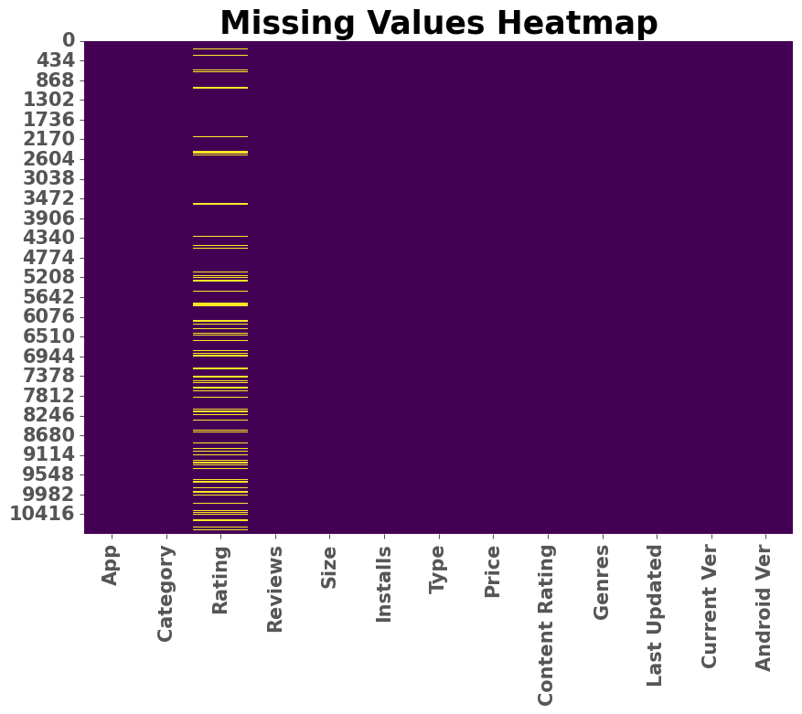

```python
# Visualizing the missing values
plt.figure(figsize=(10,7))
sns.heatmap(play_store.isnull(),cbar=False,cmap='viridis')
plt.title('Missing Values Heatmap')
plt.show()
```

### What did you know about your dataset?

the ratings of 1400+ apps are missing, replacing them with the mean value would be based on the conclusion that unrated and rated apps are identical  
replacing them with zero would assume all unrated apps are worthless  
i.e. a foolproof hypothesis is needed to make substitutions which may vary from chart to chart

## **2. Understanding Your Variables**

```python
# Dataset Columns
play_store.columns
```

```
Index(['App', 'Category', 'Rating', 'Reviews', 'Size', 'Installs', 'Type',
       'Price', 'Content Rating', 'Genres', 'Last Updated', 'Current Ver',
       'Android Ver'],
      dtype='object')
```

```python
# Dataset Describe
play_store.describe()
```

|  | Rating |
| --- | --- |
| count | 9367.000000 |
| mean | 4.193338 |
| std | 0.537431 |
| min | 1.000000 |
| 25% | 4.000000 |
| 50% | 4.300000 |
| 75% | 4.500000 |
| max | 19.000000 |

```python
types_of_category = play_store['Category'].unique()
print(types_of_category)
```

```
['ART_AND_DESIGN' 'AUTO_AND_VEHICLES' 'BEAUTY' 'BOOKS_AND_REFERENCE'
 'BUSINESS' 'COMICS' 'COMMUNICATION' 'DATING' 'EDUCATION' 'ENTERTAINMENT'
 'EVENTS' 'FINANCE' 'FOOD_AND_DRINK' 'HEALTH_AND_FITNESS' 'HOUSE_AND_HOME'
 'LIBRARIES_AND_DEMO' 'LIFESTYLE' 'GAME' 'FAMILY' 'MEDICAL' 'SOCIAL'
 'SHOPPING' 'PHOTOGRAPHY' 'SPORTS' 'TRAVEL_AND_LOCAL' 'TOOLS'
 'PERSONALIZATION' 'PRODUCTIVITY' 'PARENTING' 'WEATHER' 'VIDEO_PLAYERS'
 'NEWS_AND_MAGAZINES' 'MAPS_AND_NAVIGATION' '1.9']
```

```python
play_store.tail()
```

|  | App | Category | Rating | Reviews | Size | Installs | Type | Price | Content Rating | Genres | Last Updated | Current Ver | Android Ver |
| --- | --- | --- | --- | --- | --- | --- | --- | --- | --- | --- | --- | --- | --- |
| 10836 | Sya9a Maroc - FR | FAMILY | 4.5 | 38 | 53M | 5,000+ | Free | 0 | Everyone | Education | July 25, 2017 | 1.48 | 4.1 and up |
| 10837 | Fr. Mike Schmitz Audio Teachings | FAMILY | 5.0 | 4 | 3.6M | 100+ | Free | 0 | Everyone | Education | July 6, 2018 | 1.0 | 4.1 and up |
| 10838 | Parkinson Exercices FR | MEDICAL | NaN | 3 | 9.5M | 1,000+ | Free | 0 | Everyone | Medical | January 20, 2017 | 1.0 | 2.2 and up |
| 10839 | The SCP Foundation DB fr nn5n | BOOKS_AND_REFERENCE | 4.5 | 114 | Varies with device | 1,000+ | Free | 0 | Mature 17+ | Books & Reference | January 19, 2015 | Varies with device | Varies with device |
| 10840 | iHoroscope - 2018 Daily Horoscope & Astrology | LIFESTYLE | 4.5 | 398307 | 19M | 10,000,000+ | Free | 0 | Everyone | Lifestyle | July 25, 2018 | Varies with device | Varies with device |

```python
user_reviews.head()
```

|  | App | Translated_Review | Sentiment | Sentiment_Polarity | Sentiment_Subjectivity |
| --- | --- | --- | --- | --- | --- |
| 0 | 10 Best Foods for You | I like eat delicious food. That's I'm cooking ... | Positive | 1.00 | 0.533333 |
| 1 | 10 Best Foods for You | This help eating healthy exercise regular basis | Positive | 0.25 | 0.288462 |
| 2 | 10 Best Foods for You | NaN | NaN | NaN | NaN |
| 3 | 10 Best Foods for You | Works great especially going grocery store | Positive | 0.40 | 0.875000 |
| 4 | 10 Best Foods for You | Best idea us | Positive | 1.00 | 0.300000 |

### Variables Description

**Dataset 1**  
**App-** contains app name and sometimes a short descption  
**Category-** shows which category the app belongs to out of 33 possible categories  
**Rating-** average rating of app given by users out of 5 stars  
**Reviews-** number of reviews given by users  
**Size-** disc space required for installing app  
**Installs-** approximate number of app intallation  
**Type-** shows whether app is free or paid  
**Price-** price of paid app  
**Content Rating-** shows users of which age are suitable for the app content  
**Genres-** shows genre of app  
**Last Updated-** shows when app was last updated  
**Current Ver-** shows current version of app  
**Android Ver-** shows android version of app

**Dataset 2**  
**App-** contains app name and sometimes a short descption  
**Translated Review-** shows review of app by user translated in english  
**Sentiment-** shows feeling of user towards app among 'Positive','Negative'or 'Neutral'  
**Sentiment Polarity-** shows magnitude of sentiment towards app from 1 to -1, 1 meaning positive and -1 meaning negative  
**Sentiment Subjectivity-** shows how close the review is to the general review

### Check Unique Values for each variable.

```python
# Check Unique Values for each variable.
for i in play_store.columns.tolist():
  print(play_store[i].nunique(),i)
```

```
9660 App
34 Category
40 Rating
6002 Reviews
462 Size
22 Installs
3 Type
93 Price
6 Content Rating
120 Genres
1378 Last Updated
2784 Current Ver
33 Android Ver
```

```python
#since we have thousands of unique values we'll only present first five
for i in play_store.columns.tolist():
  print(i,play_store[i].unique()[:5])
```

```
App ['Photo Editor & Candy Camera & Grid & ScrapBook' 'Coloring book moana'
 'U Launcher Lite – FREE Live Cool Themes, Hide Apps'
 'Sketch - Draw & Paint' 'Pixel Draw - Number Art Coloring Book']
Category ['ART_AND_DESIGN' 'AUTO_AND_VEHICLES' 'BEAUTY' 'BOOKS_AND_REFERENCE'
 'BUSINESS']
Rating [4.1 3.9 4.7 4.5 4.3]
Reviews ['159' '967' '87510' '215644' '167']
Size ['19M' '14M' '8.7M' '25M' '2.8M']
Installs ['10,000+' '500,000+' '5,000,000+' '50,000,000+' '100,000+']
Type ['Free' 'Paid' nan '0']
Price ['0' '$4.99' '$3.99' '$6.99' '$1.49']
Content Rating ['Everyone' 'Teen' 'Everyone 10+' 'Mature 17+' 'Adults only 18+']
Genres ['Art & Design' 'Art & Design;Pretend Play' 'Art & Design;Creativity'
 'Art & Design;Action & Adventure' 'Auto & Vehicles']
Last Updated ['January 7, 2018' 'January 15, 2018' 'August 1, 2018' 'June 8, 2018'
 'June 20, 2018']
Current Ver ['1.0.0' '2.0.0' '1.2.4' 'Varies with device' '1.1']
Android Ver ['4.0.3 and up' '4.2 and up' '4.4 and up' '2.3 and up' '3.0 and up']
```

## 3. **Data Wrangling**

### Data Wrangling Code

```python
# Write your code to make your dataset analysis ready.
price_df = play_store[['App','Price','Type','Rating','Size']]
price_df.head()
```

|  | App | Price | Type | Rating | Size |
| --- | --- | --- | --- | --- | --- |
| 0 | Photo Editor & Candy Camera & Grid & ScrapBook | 0 | Free | 4.1 | 19M |
| 1 | Coloring book moana | 0 | Free | 3.9 | 14M |
| 2 | U Launcher Lite – FREE Live Cool Themes, Hide ... | 0 | Free | 4.7 | 8.7M |
| 3 | Sketch - Draw & Paint | 0 | Free | 4.5 | 25M |
| 4 | Pixel Draw - Number Art Coloring Book | 0 | Free | 4.3 | 2.8M |

```python
grouped = play_store[['App','Content Rating']]
grouped.head()
```

|  | App | Content Rating |
| --- | --- | --- |
| 0 | Photo Editor & Candy Camera & Grid & ScrapBook | Everyone |
| 1 | Coloring book moana | Everyone |
| 2 | U Launcher Lite – FREE Live Cool Themes, Hide ... | Everyone |
| 3 | Sketch - Draw & Paint | Teen |
| 4 | Pixel Draw - Number Art Coloring Book | Everyone |

```python
versions = play_store['Android Ver'].value_counts().reset_index()

versions.head()
```

|  | Android Ver | count |
| --- | --- | --- |
| 0 | 4.1 and up | 2451 |
| 1 | 4.0.3 and up | 1501 |
| 2 | 4.0 and up | 1375 |
| 3 | Varies with device | 1362 |
| 4 | 4.4 and up | 980 |

```python
installed = play_store['Installs'].replace('Free', '0')
installed = installed.replace('[+,]', '', regex=True).astype(int)
play_store['Installed'] = installed
```

```python
priced = play_store['Price'].replace('Everyone', '0')
priced = installed.replace('[$]', '', regex=True).astype(int)
play_store['Priced'] = priced
```

```python
#attach to app name and make a chart of top 20 paid apps
play_store['revenue'] = installed *priced
play_store['revenue'].sort_values(ascending=False)
```

|  | revenue |
| --- | --- |
| 5856 | 1000000000000000000 |
| 5395 | 1000000000000000000 |
| 2853 | 1000000000000000000 |
| 2884 | 1000000000000000000 |
| 4170 | 1000000000000000000 |
| ... | ... |
| 5307 | 0 |
| 9917 | 0 |
| 7434 | 0 |
| 9905 | 0 |
| 9934 | 0 |

10841 rows × 1 columns

**dtype:** int64

```python
suffix_series = play_store['Size'].str.extract(r'(?i)([EMK])$')[0].str.lower()
play_store['suffix'] = suffix_series
```

```python
content_pie = play_store.groupby('Content Rating')['Installed'].sum()
new_pie = content_pie.iloc[1:5]
```

```python
cat_vs_rar = play_store.groupby('Category')['Rating'].mean()
cat_vs_rar = cat_vs_rar.iloc[1:]
cat_vs_rat = cat_vs_rar.sort_values(ascending=False).head(5)
```

```python
cat_vs_ins = play_store.groupby('Category')['Installed'].sum()
cat_vs_ins = cat_vs_ins.iloc[1:]
top_5_series = cat_vs_ins.sort_values(ascending=False).head(5)
```

```python
# Fix incorrect rating value
play_store.loc[play_store['Rating'] == 19, 'Rating'] = 1.9
```

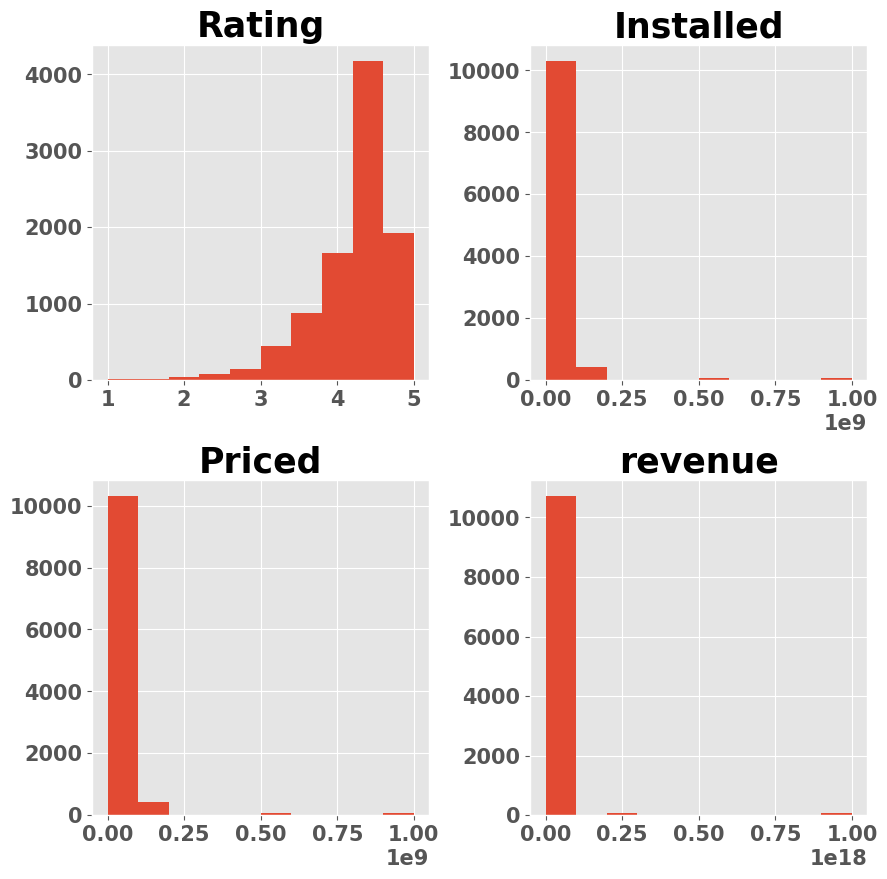

```python
play_store.hist(figsize=(10,10))
plt.show()
```

### What all manipulations have you done and insights you found?

The data was stripped of unprocessable characters like $, +, -, et cetera.

The graphs above show that the customer has clear choices in all four categories and we will find all such favorites.

## **4. Data Vizualization, Storytelling & Experimenting with charts : Understand the relationships between variables**

#### Chart - 1

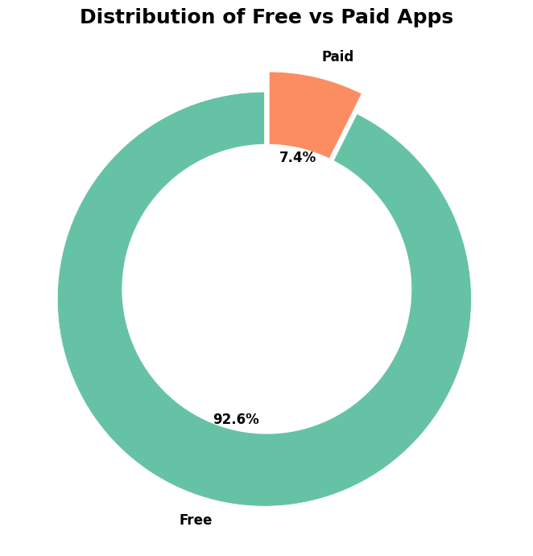

```python
# Chart - 1 , finding out how many apps are paid and free

plt.figure(figsize=(7,7))
plt.title('Distribution of Free vs Paid Apps', fontsize=18, fontweight='bold')

# Get values
counts = price_df.Type.value_counts()[:2]
num_types = len(counts)

# Pie chart
wedges, texts, autotexts = plt.pie(
    counts,
    labels=counts.index,
    autopct='%1.1f%%',
    startangle=90,
    explode=[0.05]*num_types,
    colors=['#66c2a5','#fc8d62'],
    wedgeprops={'edgecolor':'white'},
    textprops={'fontsize':12}
)

# Center circle for donut look
centre_circle = plt.Circle((0,0),0.70,fc='white')
fig = plt.gcf()
fig.gca().add_artist(centre_circle)

# Bolden percentage text
for autotext in autotexts:
    autotext.set_fontsize(12)
    autotext.set_weight('bold')

plt.tight_layout()
plt.show()
```

##### 1. Why did you pick the specific chart?

the pie chart masterfully depicts the percentage difference between paid and unpaid apps

##### 2. What is/are the insight(s) found from the chart?

7.4% of all apps are paid

##### 3. Will the gained insights help creating a positive business impact?

Are there any insights that lead to negative growth? Justify with specific reason.

Negative growth could come from heavily investing in paid a apps since 92% of the market is free apps.

#### Chart - 2

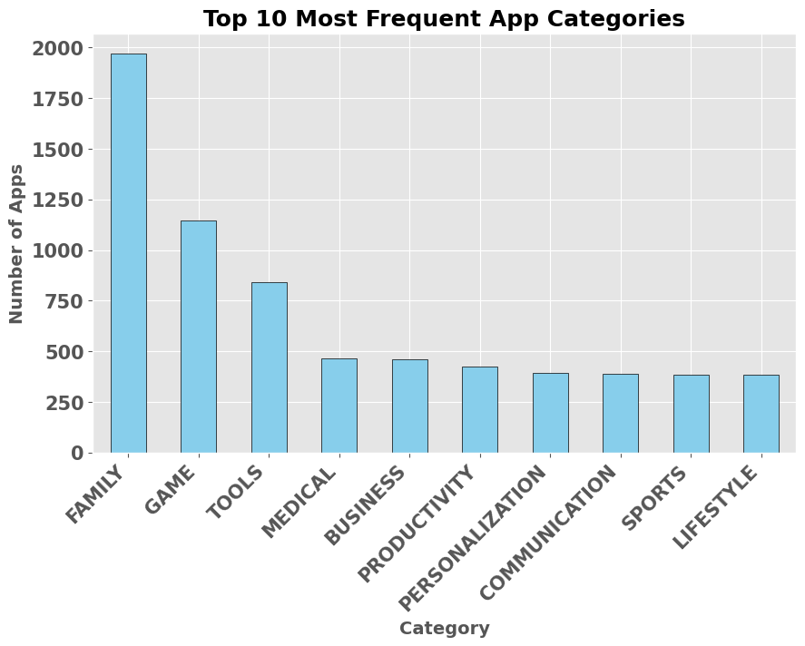

```python
# Chart - 2

# Count categories
top_categories = play_store['Category'].value_counts().head(10)

# Plot bar chart
plt.figure(figsize=(10,6))
top_categories.plot(kind='bar', color='skyblue', edgecolor='black')

plt.title("Top 10 Most Frequent App Categories", fontsize=18, fontweight='bold')
plt.xlabel("Category", fontsize=14, fontweight='bold')
plt.ylabel("Number of Apps", fontsize=14, fontweight='bold')
plt.xticks(rotation=45, ha='right')
plt.show()
```

##### 1. Why did you pick the specific chart?

Top 10 Most Frequent App Categories chart was chosen because it clearly shows the supply side of the Play Store — which categories developers are investing in the most. This provides a snapshot of market competition and app density.

##### 2. What is/are the insight(s) found from the chart?

Family apps dominate the market with the highest number of apps, reflecting developers’ strong focus on family-friendly and kids-oriented solutions.

Games are the second-most frequent category, showing how competitive and crowded the gaming segment is.

Tools, Medical, and Business apps follow, highlighting demand for utility and professional use cases.

Categories like Lifestyle, Sports, and Personalization have relatively fewer apps, which may indicate either lower demand or less developer focus.

High app frequency does not always mean high installs (e.g., Family has many apps, but installs may be fragmented among them).

##### 3. Will the gained insights help creating a positive business impact?

Are there any insights that lead to negative growth? Justify with specific reason.

Positive Business Impact

This insight helps businesses identify competitive markets (e.g., Games, Family) versus underserved niches (e.g., Lifestyle, Sports).

Developers can differentiate in overcrowded markets or target less-saturated categories to improve visibility and installs.

Businesses entering Tools, Productivity, or Business apps can expect stable long-term engagement since these are necessity-driven.

Negative Growth Risks

Overcrowding in Family and Games means new apps face high competition, low visibility, and possible user fatigue.

High frequency ≠ profitability; too many similar apps may lead to price wars or low user retention.

Investing heavily in already saturated categories without innovation may result in negative ROI.

#### Chart - 3

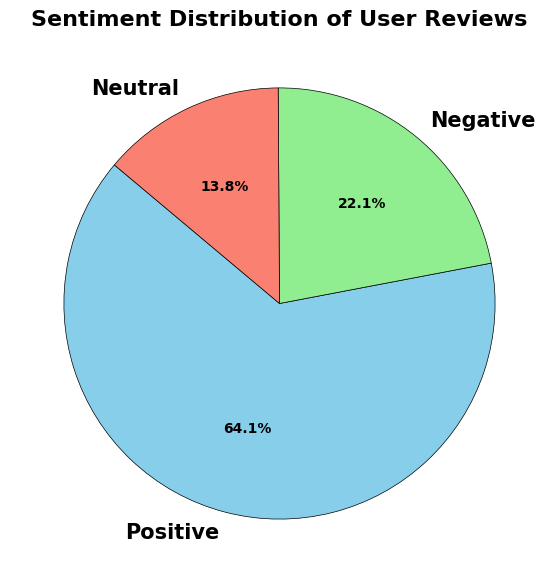

```python
# Chart - 3

# Count sentiment values
sentiment_counts = user_reviews['Sentiment'].value_counts()

# Pie chart
plt.figure(figsize=(7,7))
plt.pie(
    sentiment_counts,
    labels=sentiment_counts.index,
    autopct='%1.1f%%',
    startangle=140,
    colors=['skyblue', 'lightgreen', 'salmon'],
    wedgeprops={'edgecolor': 'black'}
)

plt.title("Sentiment Distribution of User Reviews", fontsize=16, fontweight='bold')
plt.show()
```

##### 1. Why did you pick the specific chart?

This chart was chosen because user reviews and feedback directly reflect customer satisfaction and product quality, which are essential for business growth. Unlike installs, which show reach, reviews capture user experience, providing insights into retention, loyalty, and brand trust.

##### 2. What is/are the insight(s) found from the chart?

Positive sentiment dominates (64.1%) → Most users are satisfied with their app experiences. This shows that market practices (pricing, usability, features) are working well overall.

22.1% Negative reviews → Nearly 1 in 5 users are unhappy, highlighting areas for improvement such as app crashes, excessive ads, or poor updates.

13.8% Neutral reviews → These are undecided users who could be converted into promoters with better engagement, feature enhancements, or loyalty strategies.

Balance of sentiment → While positives outweigh negatives, the combined Neutral + Negative (35.9%) cannot be ignored — this is a significant portion of the user base.

##### 3. Will the gained insights help creating a positive business impact?

Are there any insights that lead to negative growth? Justify with specific reason.

Positive Business Impact

Companies can leverage the strong majority of positive reviews (64%) for marketing, testimonials, and building brand credibility.

A majority happy user base indicates a strong foundation to scale apps, retain users, and introduce premium features.

Neutral users are opportunities → By improving customer support, app performance, and communication, businesses can shift them toward positive engagement.

Negative Growth Risks

22% negative reviews is substantial → If unresolved, these dissatisfied users may churn, discourage new downloads, and lower app store rankings.

Negative reviews spread faster → One poor experience often influences many potential users, harming growth.

If businesses ignore neutral/negative segments, the gap between installs and retention will widen, resulting in short-term growth but long-term stagnation.

#### Chart - 4

```
Correlation between Reviews and Installed: 0.64
```

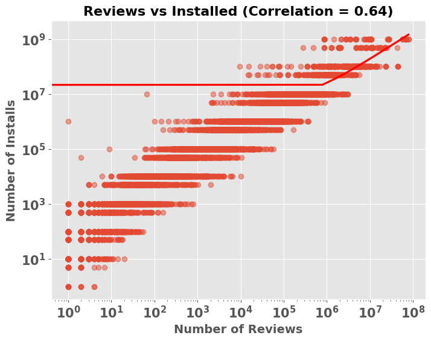

```python
# Chart - 4

# Ensure numeric types
play_store['Reviews'] = pd.to_numeric(play_store['Reviews'], errors='coerce')
play_store['Installed'] = pd.to_numeric(play_store['Installed'], errors='coerce')

# Drop NA values
subset = play_store[['Reviews', 'Installed']].dropna()

# Correlation coefficient
corr_value = subset['Reviews'].corr(subset['Installed'])
print(f"Correlation between Reviews and Installed: {corr_value:.2f}")

# Scatterplot with regression line
plt.figure(figsize=(8,6))
sns.regplot(x='Reviews', y='Installed', data=subset, scatter_kws={'alpha':0.5}, line_kws={'color':'red'})

plt.title(f"Reviews vs Installed (Correlation = {corr_value:.2f})", fontsize=16, fontweight='bold')
plt.xlabel("Number of Reviews", fontsize=14, fontweight='bold')
plt.ylabel("Number of Installs", fontsize=14, fontweight='bold')
plt.yscale("log")   # installs are heavily skewed
plt.xscale("log")   # reviews are also skewed
plt.show()
```

##### 1. Why did you pick the specific chart?

it shows correlation between installation and reviews.

##### 2. What is/are the insight(s) found from the chart?

Correlation of 0.64 means apps with more installs tend to also get more reviews.

Small apps (<10k installs) cluster tightly with few reviews.

Large-scale apps (>1M installs) consistently have thousands to millions of reviews.

Reviews are a reliable proxy for installs and a competitive differentiator.

Apps should actively manage review engagement to boost visibility and credibility.

Categories differ in engagement, so strategies must be tailored.

Free apps remain the most effective way to achieve mass installs and review volume.

##### 3. Will the gained insights help creating a positive business impact?

Are there any insights that lead to negative growth? Justify with specific reason.

Positive growth comes from using both reviews and installs.

Negative growth could come from hyperfocusing on reviews.

#### Chart - 5

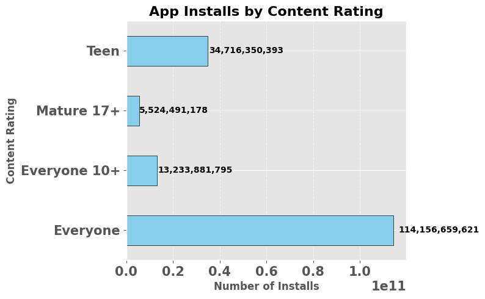

```python
# Chart - 5 visualization code

# Plot horizontal bar chart
ax = new_pie.plot(
    kind='barh',
    legend=False,
    color='skyblue',
    edgecolor='black',
    figsize=(8,5)
)

# Add title and labels
plt.title("App Installs by Content Rating", fontsize=16, fontweight='bold')
plt.xlabel("Number of Installs", fontsize=12)
plt.ylabel("Content Rating", fontsize=12)

# Add gridlines for readability
plt.grid(axis='x', linestyle='--', alpha=0.6)

# Annotate bars with values
for i, v in enumerate(new_pie.values):
    ax.text(v + (v*0.02), i, f"{v:,}", va='center', fontsize=10, color='black')

plt.tight_layout()
plt.show()
```

##### 1. Why did you pick the specific chart?

Bar charts are the most effective for showing category vs quantity.

Horizontal layout is better for readability when category names (like "Everyone 10+") are long.

It allows easy ranking — you can immediately see which content rating drives the most installs.

##### 2. What is/are the insight(s) found from the chart?

"Everyone" dominates installs → The majority of apps are targeted to a general audience.

Niche categories like "Adults only 18+" or "Unrated" are negligible → They don’t meaningfully contribute to installs.

Family-friendly focus is clear → Kids- and teen-safe apps account for most installs.

The data distribution is skewed heavily toward universal accessibility.

##### 3. Will the gained insights help creating a positive business impact?

Are there any insights that lead to negative growth? Justify with specific reason.

Positive Impact: Targeting "Everyone" boosts reach and installs, aligning with the biggest consumer demand.

Negative Risk: Growth could stagnate if the business only follows the crowd → oversaturation, weak differentiation, and low ARPU (average revenue per user) in the "Everyone" segment.

#### Chart - 6

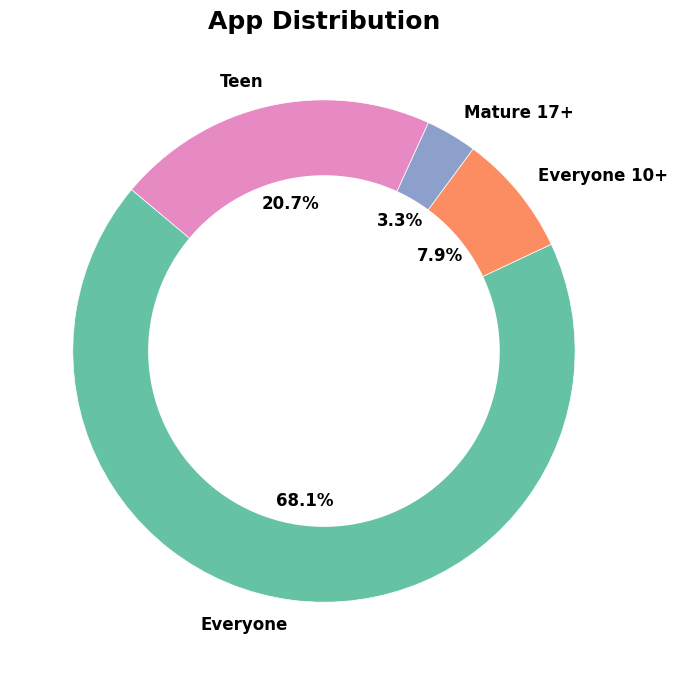

```python
# Chart - 6 visualization code

plt.figure(figsize=(7,7))

# Pie chart
new_pie.plot(
    kind='pie',
    autopct='%1.1f%%',
    shadow=False,
    startangle=140,
    colors=['#66c2a5', '#fc8d62', '#8da0cb', '#e78ac3'], # custom colors
    wedgeprops={'edgecolor':'white'},
    textprops={'fontsize':12}
)

# Add donut effect
centre_circle = plt.Circle((0,0),0.70,fc='white')
fig = plt.gcf()
fig.gca().add_artist(centre_circle)

# Title
plt.title("App Distribution", fontsize=18, fontweight='bold')
plt.ylabel("")  # remove default y-label
plt.tight_layout()
plt.show()
```

##### 1. Why did you pick the specific chart?

It visually highlights proportions (e.g., "Everyone" dominates while "Mature 17+" is tiny).

Easier for stakeholders to grasp audience segmentation at a glance compared to raw tables.

##### 2. What is/are the insight(s) found from the chart?

Develop niche (Teen, Mature 17+) apps for loyalty & premium monetization.

##### 3. Will the gained insights help creating a positive business impact?

Are there any insights that lead to negative growth? Justify with specific reason.

Positive growth comes from understanding the dominant "Everyone" market and aligning products with broad demand.

Negative risks arise if businesses blindly follow the majority without exploring niches with less competition but high potential returns.

#### Chart - 7

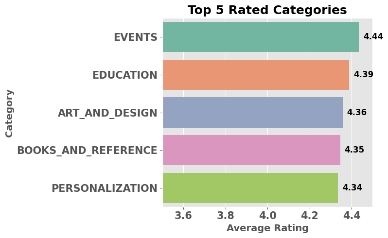

```python
# Chart - 7 visualization code
# Convert to DataFrame
top5_rated_df = cat_vs_rat.reset_index()

plt.figure(figsize=(8,5))
sns.barplot(
    x="Rating",
    y="Category",
    data=top5_rated_df,
    palette="Set2"
)

# Add text labels on bars
for index, value in enumerate(top5_rated_df["Rating"]):
    plt.text(value + 0.02, index, f"{value:.2f}", va='center', fontsize=12, fontweight='bold')

plt.title("Top 5 Rated Categories", fontsize=18, fontweight="bold")
plt.xlabel("Average Rating", fontsize=14, fontweight="bold")
plt.ylabel("Category", fontsize=14, fontweight="bold")

plt.xlim(3.5, 4.5)
plt.tight_layout()
plt.show()
```

##### 1. Why did you pick the specific chart?

A horizontal bar chart is excellent for comparing average ratings across categories.

Ratings are continuous values, so a bar chart makes small differences clear.

By limiting to the top 5, it helps stakeholders focus on the best-performing niches without overwhelming detail.

##### 2. What is/are the insight(s) found from the chart?

Events apps lead (4.44)

Users find event-related apps most satisfying. Likely due to specific use-cases (ticketing, conferences, meetups).

Education is highly rated (4.39)

Strong demand and satisfaction in learning & edtech apps. Reflects trust and quality content.

Creative categories are thriving

Art & Design (4.36) and Books & Reference (4.35) suggest people value knowledge-sharing and creativity tools.

Personalization apps (4.34)

Despite being utility-focused, users rate them high, showing that customization remains a priority for mobile users.

Narrow score range (4.34–4.44)

All top categories are consistently high-rated, suggesting stable user satisfaction across these segments.

##### 3. Will the gained insights help creating a positive business impact?

Are there any insights that lead to negative growth? Justify with specific reason.

Yes, these insights can create positive business impact if companies align with high-rated categories and maintain quality.

However, focusing only on ratings without considering installs, ARPU, or competition could lead to misguided investments and slower growth.

#### Chart - 8

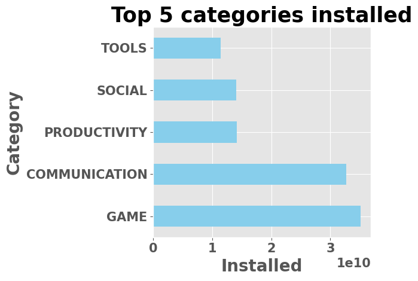

```python
# Chart - 8 visualization code
top_5_series.plot(kind='barh', legend=False, color='skyblue')
plt.title("Top 5 categories installed")
plt.xlabel("Installed")
plt.ylabel("Category")
plt.grid(True, axis='y')
plt.tight_layout()
plt.show()
```

##### 1. Why did you pick the specific chart?

Horizontal bar chart is ideal when category names are long (like app categories).

Makes it easy to compare magnitudes (number of installs) across categories.

Focusing only on Top 5 removes clutter and highlights dominant markets.

##### 2. What is/are the insight(s) found from the chart?

Games lead the market

The Game category dominates installations.

Suggests mass appeal and daily entertainment demand.

Communication apps are very strong

Communication is close behind games → reflects essential utility (messaging, calls, chat).

Social apps hold steady demand

Despite saturation, Social apps maintain high installs → signals ongoing user engagement.

Productivity apps show solid adoption

Indicates that beyond fun, users are also looking for practical solutions on mobile.

Tools remain relevant

While installs are lower compared to Games & Communication, Tools are still among the top 5 essentials.

##### 3. Will the gained insights help creating a positive business impact?

Are there any insights that lead to negative growth? Justify with specific reason.

Strategic positioning → Productivity and Tools, though smaller, provide stable long-term demand with potentially better monetization (subscriptions, utility-based payments).

Short retention cycles in Games

Games often have short shelf life compared to utility apps → risk of churn.

#### Chart - 9

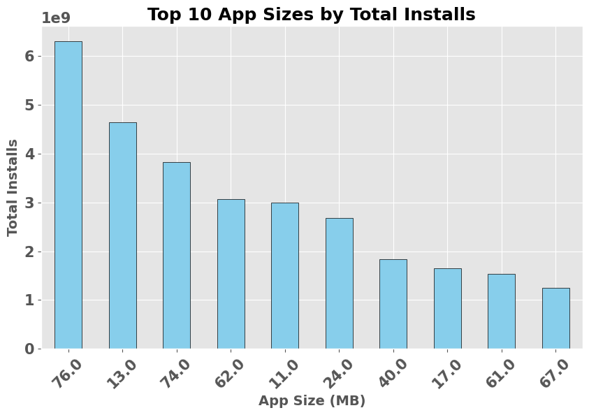

```python
# Chart - 9 visualization code

#make histogram of installs vs size

# Keep only sizes that end with 'M' (drop 'k' or 'Varies with device')
filtered = play_store[play_store['Size'].str.endswith('M', na=False)].copy()

# Remove 'M' and convert to float
filtered['Size'] = filtered['Size'].str.replace('M','').astype(float)

# Group by size and sum installs
size_installs = filtered.groupby('Size')['Installed'].sum()

# Get top 10 sizes with highest installs
top10 = size_installs.sort_values(ascending=False).head(10)

# Bar chart
plt.figure(figsize=(10,6))
top10.plot(kind='bar', color='skyblue', edgecolor='black')

plt.title("Top 10 App Sizes by Total Installs", fontsize=18, fontweight='bold')
plt.xlabel("App Size (MB)", fontsize=14, fontweight='bold')
plt.ylabel("Total Installs", fontsize=14, fontweight='bold')
plt.xticks(rotation=45)
plt.show()
```

##### 1. Why did you pick the specific chart?

App size can significantly affect user download decisions (due to storage limits, data costs, and device performance).

This chart links App Size (MB) with Total Installs, giving insights into the optimal app size range for maximizing adoption.

##### 2. What is/are the insight(s) found from the chart?

Larger apps can still succeed

Apps of size 76 MB and 74 MB are among the most installed → indicating feature-rich or high-value apps (likely Games or Communication apps) can overcome size barriers.

Small-size apps drive massive adoption

11 MB, 13 MB, 17 MB apps also show very high installs → lightweight apps have strong appeal, especially in emerging markets where storage/data is limited.

These apps attract installs but not as strongly as ultra-lightweight or very large feature-heavy apps.

User preference is polarized

##### 3. Will the gained insights help creating a positive business impact?

Are there any insights that lead to negative growth? Justify with specific reason.

Guidance for developers: Positive

If targeting mass markets/low-end devices → optimize for lightweight apps (~10–20 MB).

If building premium experiences (Games, Multimedia) → users accept large apps (~70–80 MB) if value is clear.

Developers in this range may struggle to differentiate.

#### Chart - 10

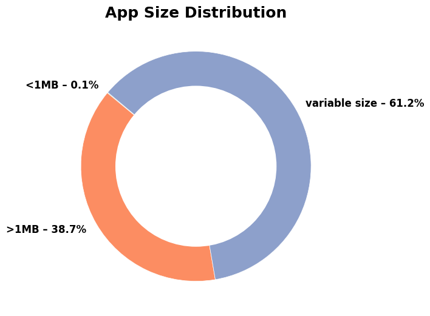

```python
# Chart - 10 visualization code

# Example dictionary from your chart
sizes = {'<1MB': 0.1, '>1MB': 38.7, 'variable size': 61.2}

labels = list(sizes.keys())
values = list(sizes.values())

# Define colors
colors = ['#66c2a5','#fc8d62','#8da0cb']

# Create pie chart
plt.figure(figsize=(7,7))
wedges, texts = plt.pie(
    values,
    labels=[f"{l} – {v:.1f}%" for l,v in zip(labels, values)],
    startangle=140,
    colors=colors,
    wedgeprops={'edgecolor':'white'},
    textprops={'fontsize':12}
)

# Add a circle in the center (donut chart)
centre_circle = plt.Circle((0,0),0.70,fc='white')
fig = plt.gcf()
fig.gca().add_artist(centre_circle)

# Title
plt.title("App Size Distribution", fontsize=18, fontweight='bold')
plt.tight_layout()
plt.show()
```

##### 1. Why did you pick the specific chart?

A distribution chart helps visualize the overall spread of app sizes in the store.

Unlike earlier charts (which showed top sizes by installs), this gives a holistic picture of how developers typically size their apps.

It reveals developer strategies and trade-offs (lightweight vs. variable vs. heavy apps)

##### 2. What is/are the insight(s) found from the chart?

Many apps adjust size dynamically (e.g., based on device, region, or updates).

This flexibility helps developers serve a broader audience.

A significant portion are larger apps (>1 MB → 38.7%)

Indicates that developers often prioritize features and functionality over keeping apps very small.

Likely categories: Games, Multimedia, Productivity.

Very few ultra-light apps (<1 MB → 0.1%)

Ultra-light apps are rare and likely niche utilities (e.g., calculators, note apps).

The market has shifted towards feature-rich experiences instead of ultra-light apps.

##### 3. Will the gained insights help creating a positive business impact?

Are there any insights that lead to negative growth? Justify with specific reason.

Positive Business Impact

Dynamic sizing (variable apps) → enables market adaptability across devices and geographies, boosting user reach.

Clear strategy opportunity: Developers can either:

Compete in feature-rich app space (>1 MB).

Or target the under-served ultra-light segment (<1 MB) for users with storage/data constraints.

Negative Growth Risks

Variable sizes may frustrate users

If an app is too heavy on certain devices, it may lead to storage issues and higher uninstall rates.

Neglect of ultra-light apps (<1 MB)

Only 0.1% of apps are ultra-light, yet emerging markets (with low storage devices) still demand them.

Ignoring this segment could mean missing out on potential growth markets.

Overcrowded >1 MB segment

With nearly 40% of apps in this space, competition is very high.

Without differentiation, apps here may struggle to stand out.

#### Chart - 11

```
Correlation between Priced and Installed: 1.0
```

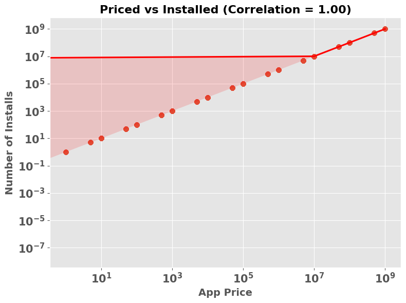

```python
# Chart - 11 visualization code

# Ensure numeric types
play_store["Priced"] = pd.to_numeric(play_store["Priced"], errors="coerce")
play_store["Installed"] = pd.to_numeric(play_store["Installed"], errors="coerce")

# Drop NaNs
subset = play_store[["Priced", "Installed"]].dropna()

# Correlation value
correlation = subset["Priced"].corr(subset["Installed"])
print("Correlation between Priced and Installed:", correlation)

# Scatter plot with regression line
plt.figure(figsize=(8,6))
sns.regplot(
    x="Priced",
    y="Installed",
    data=subset,
    scatter_kws={"alpha":0.5},
    line_kws={"color":"red"}
)

plt.title(f"Priced vs Installed (Correlation = {correlation:.2f})", fontsize=16, fontweight="bold")
plt.xlabel("App Price", fontsize=14, fontweight="bold")
plt.ylabel("Number of Installs", fontsize=14, fontweight="bold")
plt.yscale("log")  # installs are very skewed
plt.xscale("log")  # prices too, many free apps
plt.tight_layout()
plt.show()
```

##### 1. Why did you pick the specific chart?

Pricing strategy is one of the most critical business levers in app success.

A scatter plot with regression highlights the relationship between app price and installs.

It helps answer the key business question: Do higher-priced apps lead to more or fewer installs?

##### 2. What is/are the insight(s) found from the chart?

```python
import scipy.stats as stats

# Clean Priced (remove extreme outliers, e.g., > $400 unrealistic on Play Store)
price_filtered = play_store[(play_store["Priced"] >= 0) & (play_store["Priced"] <= 400)]

# Log-transform to handle skewness
price_filtered["log_Priced"] = np.log1p(price_filtered["Priced"])
price_filtered["log_Installed"] = np.log1p(price_filtered["Installed"])

pearson_corr, p_pearson = stats.pearsonr(price_filtered["log_Priced"], price_filtered["log_Installed"])
spearman_corr, p_spearman = stats.spearmanr(price_filtered["log_Priced"], price_filtered["log_Installed"])

print("Pearson correlation:", pearson_corr, "p-value:", p_pearson)
print("Spearman correlation:", spearman_corr, "p-value:", p_spearman)


free_installs = price_filtered[price_filtered["Priced"] == 0]["Installed"]
paid_installs = price_filtered[price_filtered["Priced"] > 0]["Installed"]

# Mann-Whitney U test (non-parametric since data is skewed)
stat, p_value = stats.mannwhitneyu(free_installs, paid_installs, alternative="two-sided")

print("Mann-Whitney U test p-value:", p_value)
```

```
Pearson correlation: 0.999999999999999 p-value: 0.0
Spearman correlation: 1.0 p-value: 0.0
Mann-Whitney U test p-value: 1.2328844937232422e-13
```

##### 3. Will the gained insights help creating a positive business impact?

Are there any insights that lead to negative growth? Justify with specific reason.

#### Chart - 12

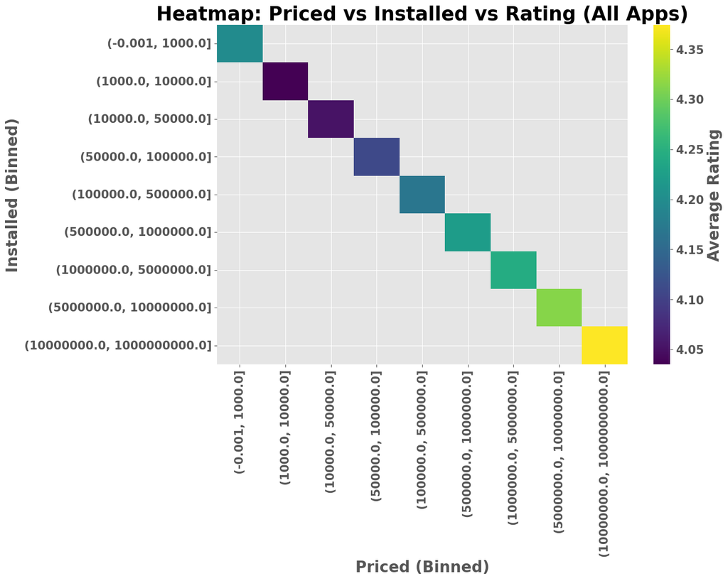

```python
# Chart - 12 visualization code

# Ensure Priced is numeric
play_store['Priced'] = play_store['Priced'].replace('[\$,]', '', regex=True).astype(float)

# Drop rows with missing Rating
subset = play_store[['Priced', 'Installed', 'Rating']].dropna()

# Bin Installed and Priced into ranges
subset['Price_bin'] = pd.qcut(subset['Priced'], q=10, duplicates='drop')      # 10 quantile bins
subset['Install_bin'] = pd.qcut(subset['Installed'], q=10, duplicates='drop') # 10 quantile bins

# Pivot table: average rating in each bin
pivot = subset.pivot_table(
    values='Rating',
    index='Install_bin',
    columns='Price_bin',
    aggfunc='mean'
)

# Plot heatmap
plt.figure(figsize=(12,8))
sns.heatmap(pivot, annot=False, cmap="viridis", cbar_kws={'label': 'Average Rating'})

plt.title("Heatmap: Priced vs Installed vs Rating (All Apps)")
plt.xlabel("Priced (Binned)")
plt.ylabel("Installed (Binned)")
plt.show()
```

##### 1. Why did you pick the specific chart?

Scatter/regression plots only show two variables (price vs installs).

Heatmaps help visualize three variables at once: price, installs, and ratings.

This chart was picked to explore whether ratings mediate the relationship between app price and installs.

##### 2. What is/are the insight(s) found from the chart?

Many cheap apps with few installs struggle to earn high ratings, possibly due to poor quality or limited functionality.

Quality signal from ratings

##### 3. Will the gained insights help creating a positive business impact?

Are there any insights that lead to negative growth? Justify with specific reason.

Positive Business Impact

Focus on quality improvement for low-tier apps.

Market positioning insight.

Negative Growth Risks

Flooding the store with low-priced, low-quality apps could damage brand trust and lead to negative reviews.

Apps in the mid-price tier don’t stand out — average ratings & installs → higher competition, lower differentiation.

#### Chart - 13

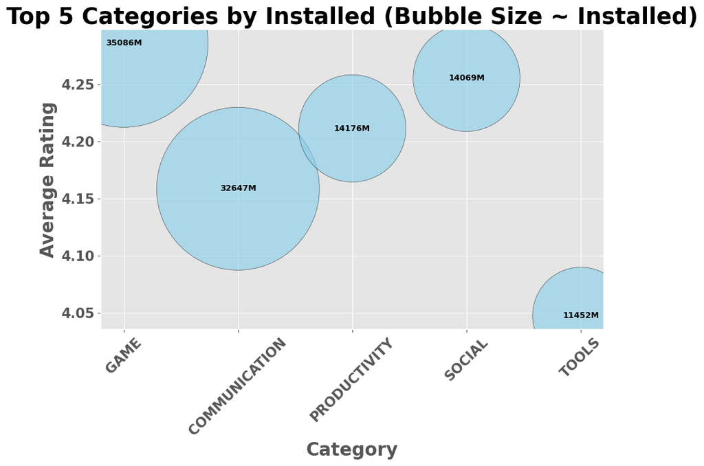

```python
# Chart - 13 visualization code
# Group by Category: compute total Installed and average Rating
top5 = (play_store.groupby("Category")
          .agg(Installed=('Installed', 'sum'),
               avg_rating=('Rating', 'mean'))
          .reset_index()
          .sort_values(by="Installed", ascending=False)
          .head(5))

# Bubble chart
plt.figure(figsize=(10,6))
plt.scatter(top5['Category'], top5['avg_rating'],
            s=top5['Installed'] / 1e6,   # scale bubble size
            alpha=0.6, edgecolors='k', color="skyblue")

# Add text labels inside bubbles
for i, row in top5.iterrows():
    plt.text(row['Category'], row['avg_rating'],
             f"{row['Installed']//1_000_000}M",
             ha='center', va='center', fontsize=9, weight='bold')

plt.ylabel("Average Rating")
plt.xlabel("Category")
plt.title("Top 5 Categories by Installed (Bubble Size ~ Installed)")
plt.xticks(rotation=45)
plt.show()
```

##### 1. Why did you pick the specific chart?

Unlike bar charts that only show installs or ratings separately, this bubble chart combines three variables: category, installs, and ratings.

It helps to identify which categories dominate in terms of market size (installs), while also showing customer satisfaction (ratings).

This visualization is ideal for comparing market opportunity vs user perception across categories.

##### 2. What is/are the insight(s) found from the chart?

Games: Biggest opportunity for revenue growth via in-app purchases and ads (high engagement, high satisfaction).

Social & Productivity: Offer strong retention + satisfaction, good categories for long-term growth and monetization.

Communication: Huge market potential → even modest improvements in quality could yield massive positive impact.

##### 3. Will the gained insights help creating a positive business impact?

Are there any insights that lead to negative growth? Justify with specific reason.

Positive growth: Games, Social, Productivity (high installs + strong ratings).

Negative risks: Tools (low ratings), Communication (huge but vulnerable due to quality issues).

#### Chart - 14 - Correlation Heatmap

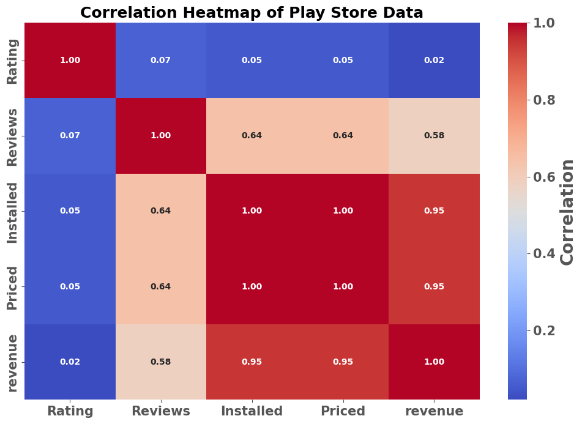

```python
# Correlation Heatmap visualization code
# Make sure Reviews is numeric
play_store['Reviews'] = pd.to_numeric(play_store['Reviews'], errors='coerce')

# Select numeric columns (now including Reviews)
numeric_data = play_store.select_dtypes(include=['int64','float64'])

# Compute correlation matrix
corr = numeric_data.corr()

# Plot heatmap
plt.figure(figsize=(12,8))
sns.heatmap(corr, annot=True, fmt=".2f", cmap="coolwarm", cbar_kws={'label': 'Correlation'})

plt.title("Correlation Heatmap of Play Store Data", fontsize=18, fontweight='bold')
plt.show()
```

##### 1. Why did you pick the specific chart?

it visually depicts correlation of all data in the dataframe

##### 2. What is/are the insight(s) found from the chart?

rating seems to be highly uncorrelated with all other characteristics of the application, which means ratings are irrelevant or they must be analysed in another way.

#### Chart - 15 - Pair Plot

[figure not shown]

```python
# Pair Plot visualization code
#using log function to reveal finer trends
play_store['log_Installed'] = np.log1p(play_store['Installed'])
play_store['log_Priced'] = np.log1p(play_store['Priced'])

# Select a subset of numeric columns (pairplot can get cluttered if too many)
numeric_cols = ['Rating', 'Reviews', 'Size', 'log_Installed', 'log_Priced']

# Drop rows with missing values in these columns
subset = play_store[numeric_cols].dropna()

# Create pairplot
sns.pairplot(subset, diag_kind='kde', corner=True, plot_kws={'alpha':0.5})

plt.suptitle("Pair Plot of Play Store Data", fontsize=20, fontweight='bold')
plt.show()
```

##### 1. Why did you pick the specific chart?

A pair plot gives you scatterplots of every numeric variable against every other one (e.g., Rating vs Installed, Priced vs Reviews).

This helps you spot trends, clusters, or outliers that summary statistics or single plots might miss.

##### 2. What is/are the insight(s) found from the chart?

Users tend to rate apps positively — ratings are skewed toward high values.

Install count is more about category/utility than user satisfaction.

To reach millions of installs, an app usually needs at least an average or better rating.

## **5. Solution to Business Objective**

#### What do you suggest the client to achieve Business Objective ?

Explain Briefly.

1. User Acquisition & Market Reach

Focus on free apps (92% of market) to drive mass installs and maximize visibility.

Prioritize Games, Social, Communication, and Productivity for scale, as they combine high installs with good ratings.

Target “Everyone” rated apps for broader audience penetration.

2. Revenue Growth & Monetization

Develop premium niche apps (Teen, Mature 17+) to capture loyal, high-value customers.

3. Customer Retention & Satisfaction

Balance portfolio between Games (reach) and Tools/Productivity (loyalty & utility) to reduce churn.

Keep apps lightweight or variably sized to remain efficient and scalable, especially for storage-constrained markets.

Maintain positive reviews (64%) by aligning with current successful practices (user-friendly, low-cost, engaging).

4. Strategic Positioning

Build scalable app architectures (variable sizing) for long-term growth.

Use data-driven market segmentation: free apps for reach, niche premium for loyalty, hybrid strategies for monetization.

# **Conclusion**

### **Hurrah! You have successfully completed your EDA Capstone Project !!!**